# Salmon

Jimmy Breen

18/11/2020

## Analysis of Heat Shock Proteins (HSPs) from `salmon`

After adding curated HSPs and running `salmon` to accurately quantify these transcripts, we now need to extract that information and describe the expression.

1. Load packages for the analysis

```r
library(tximport)
library(GenomicFeatures)
library(tidyverse)
```

2. Load group information for the plots later on

```r
groupInfo <- readxl::read_excel("PodarcisMuralis_TranscriptomeMetadata_jan2020.xlsx")

annot <- groupInfo %>%
  tibble::column_to_rownames(var = "TRANSCRIPTOME") %>%
  dplyr::select(-`OUR ID`, -`INDIVIDUAL`)
```

3. Load `salmon` results from the command-line information

*NOTE: LSH41 didnt work for some reason so I can removed that*

```r
dirs <- list.files("salmon/quants")
quant_files <- list.files("salmon/quants",
                          pattern="quant.sf",
                          recursive = TRUE,
                          full.names = TRUE)
names(quant_files) <- dirs
quant_files
```

```
##                           LSH1.fq.gz_quant
##  "salmon/quants/LSH1.fq.gz_quant/quant.sf"
##                          LSH10.fq.gz_quant
## "salmon/quants/LSH10.fq.gz_quant/quant.sf"
##                          LSH11.fq.gz_quant
## "salmon/quants/LSH11.fq.gz_quant/quant.sf"
##                          LSH12.fq.gz_quant
## "salmon/quants/LSH12.fq.gz_quant/quant.sf"
##                          LSH13.fq.gz_quant
## "salmon/quants/LSH13.fq.gz_quant/quant.sf"
##                          LSH14.fq.gz_quant
## "salmon/quants/LSH14.fq.gz_quant/quant.sf"
##                          LSH15.fq.gz_quant
## "salmon/quants/LSH15.fq.gz_quant/quant.sf"
##                          LSH17.fq.gz_quant
## "salmon/quants/LSH17.fq.gz_quant/quant.sf"
##                          LSH18.fq.gz_quant
## "salmon/quants/LSH18.fq.gz_quant/quant.sf"
##                          LSH19.fq.gz_quant
## "salmon/quants/LSH19.fq.gz_quant/quant.sf"
##                           LSH2.fq.gz_quant
##  "salmon/quants/LSH2.fq.gz_quant/quant.sf"
##                          LSH21.fq.gz_quant
## "salmon/quants/LSH21.fq.gz_quant/quant.sf"
##                          LSH22.fq.gz_quant
## "salmon/quants/LSH22.fq.gz_quant/quant.sf"
##                          LSH23.fq.gz_quant
## "salmon/quants/LSH23.fq.gz_quant/quant.sf"
##                          LSH24.fq.gz_quant
## "salmon/quants/LSH24.fq.gz_quant/quant.sf"
##                          LSH25.fq.gz_quant
## "salmon/quants/LSH25.fq.gz_quant/quant.sf"
##                          LSH26.fq.gz_quant
## "salmon/quants/LSH26.fq.gz_quant/quant.sf"
##                          LSH27.fq.gz_quant
## "salmon/quants/LSH27.fq.gz_quant/quant.sf"
##                          LSH28.fq.gz_quant
## "salmon/quants/LSH28.fq.gz_quant/quant.sf"
##                          LSH29.fq.gz_quant
## "salmon/quants/LSH29.fq.gz_quant/quant.sf"
```

[output cut: 31 more lines]

```
## "salmon/quants/LSH45.fq.gz_quant/quant.sf"
##                          LSH46.fq.gz_quant
## "salmon/quants/LSH46.fq.gz_quant/quant.sf"
##                          LSH47.fq.gz_quant
## "salmon/quants/LSH47.fq.gz_quant/quant.sf"
##                          LSH48.fq.gz_quant
## "salmon/quants/LSH48.fq.gz_quant/quant.sf"
##                           LSH5.fq.gz_quant
##  "salmon/quants/LSH5.fq.gz_quant/quant.sf"
##                           LSH7.fq.gz_quant
##  "salmon/quants/LSH7.fq.gz_quant/quant.sf"
##                           LSH8.fq.gz_quant
##  "salmon/quants/LSH8.fq.gz_quant/quant.sf"
##                           LSH9.fq.gz_quant
##  "salmon/quants/LSH9.fq.gz_quant/quant.sf"
```

```r
sampleNames <- gsub(".fq.gz_quant/quant.sf$", "", quant_files)
sampleNames <- gsub("^salmon/quants/", "", sampleNames)

quants <- lapply(quant_files, read_tsv)
names(quants) <- sampleNames
```

```r
quantsLess <- lapply(quants, function(x){
  x[,c(1,4)] %>%
    tibble::column_to_rownames(var = "Name")
  }
)


quantsCombined <- do.call(cbind, quantsLess)
colnames(quantsCombined) <- names(quants)
```

4. Quick clustering to see how the samples compare to each other

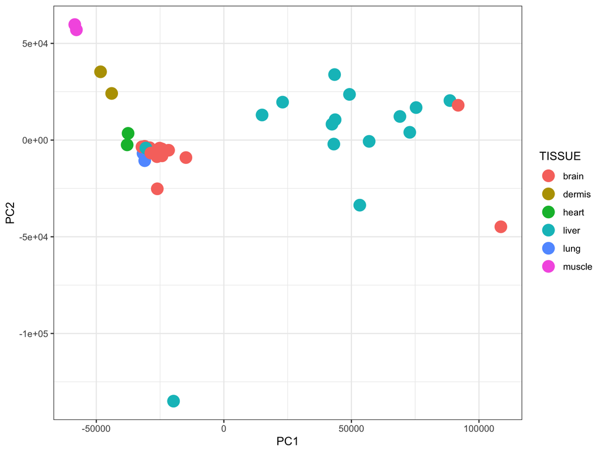

```r
df <- t(quantsCombined)

pca_res <- prcomp(df)

as.data.frame(pca_res$x) %>%
  tibble::rownames_to_column(var = "Sample") %>%
  left_join(groupInfo, by = c("Sample" = "TRANSCRIPTOME")) %>%
  ggplot(aes(PC1, PC2, colour = TISSUE)) +
  geom_point(size = 5) +
  theme_bw()
```

There are a few Brain and Liver samples that are very variable so they could be due to RIN scores

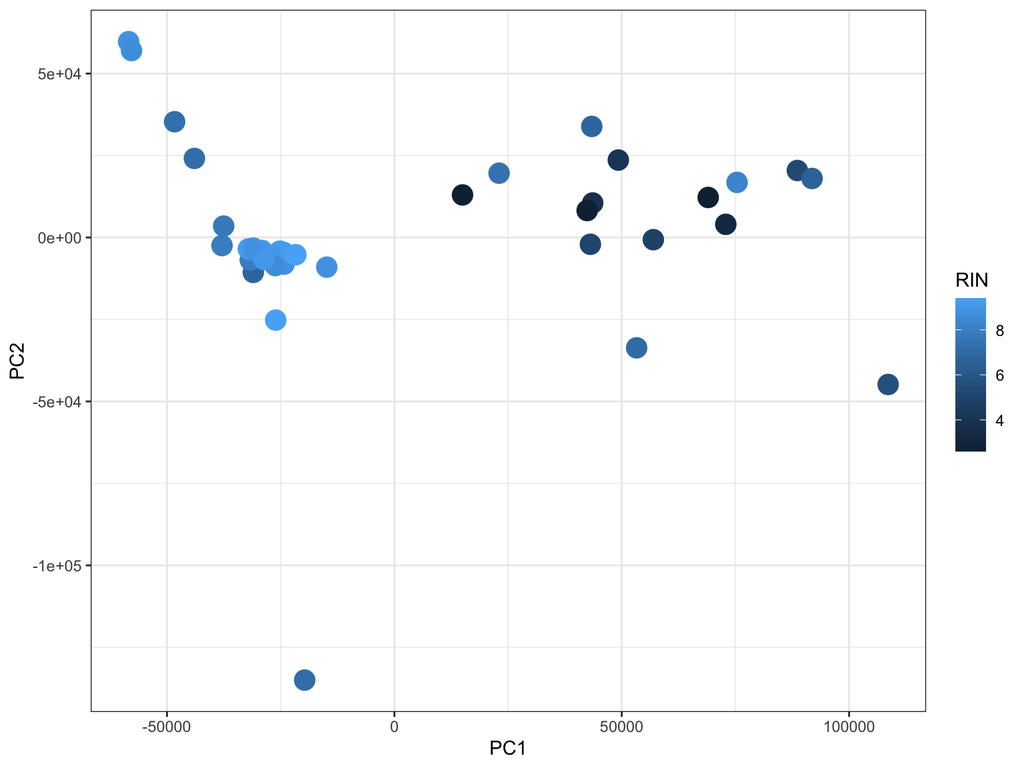

```r
as.data.frame(pca_res$x) %>%
  tibble::rownames_to_column(var = "Sample") %>%
  left_join(groupInfo, by = c("Sample" = "TRANSCRIPTOME")) %>%
  ggplot(aes(PC1, PC2, colour = RIN)) +
  geom_point(size = 5) +
  theme_bw()
```

Looking at both treatment and tissue, there does seem to be some split in treatments, which is again a very good sign!

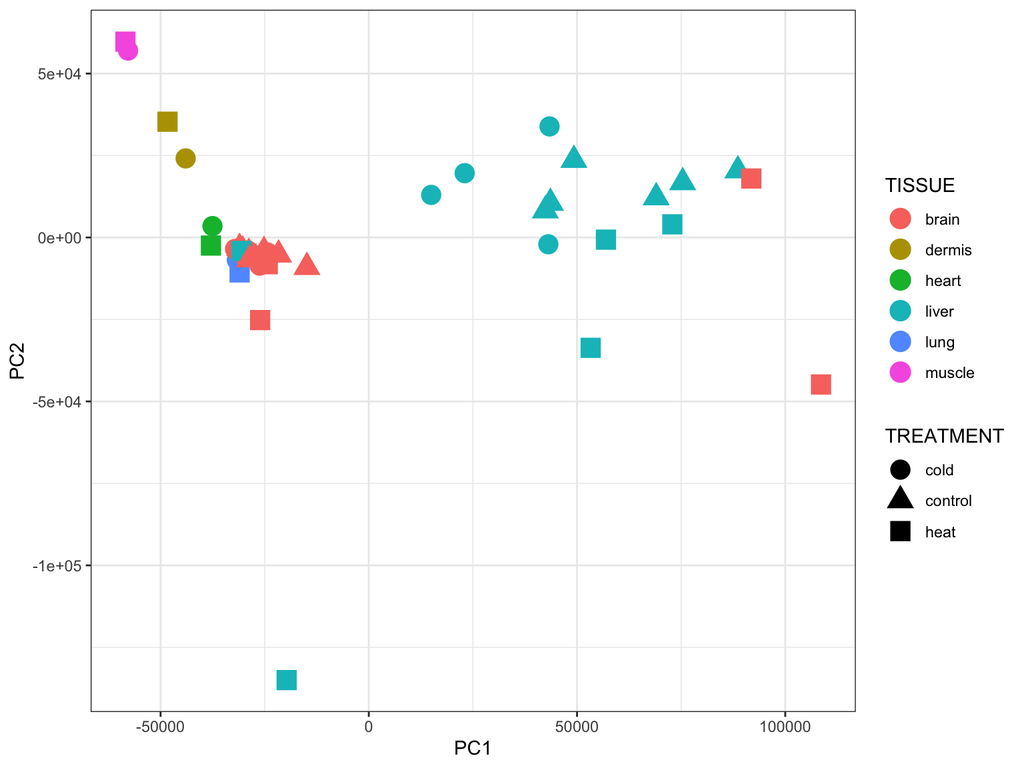

```r
as.data.frame(pca_res$x) %>%
  tibble::rownames_to_column(var = "Sample") %>%
  left_join(groupInfo, by = c("Sample" = "TRANSCRIPTOME")) %>%
  ggplot(aes(PC1, PC2, colour = TISSUE, shape = TREATMENT)) +
  geom_point(size = 5) +
  theme_bw()
```

3. Subset our data and combine into a TPM table of transcripts

Now lets boil down to the specific HSP transcripts

```r
annotatedHsps <- quantsCombined %>%
  dplyr::filter(grepl("DNA", rownames(quantsCombined)))


rownames(annotatedHsps) <- gsub("^40_", "", rownames(annotatedHsps))
rownames(annotatedHsps) <- gsub("_Podarcis_muralis", "", rownames(annotatedHsps))

head(annotatedHsps)
```

```
##                      LSH1     LSH10     LSH11     LSH12     LSH13     LSH14
## DNAJC27_Paralog2 0.000000  0.853295  5.612499  0.000000  1.815068  0.000000
## DNAJC27_Paralog1 0.000000  4.199095  0.000000  1.383928  3.554114  0.000000
## DNAJC25_Paralog2 0.000000  0.000000  3.096516  0.000000  0.000000 22.913988
## DNAJC25_Paralog1 0.000000 15.182381 19.286131 16.521087 27.668994  7.075363
## DNAJC24_Paralog2 6.065079  8.751789  6.553198  6.050056  4.547037  4.490002
## DNAJC24_Paralog1 0.000000  0.000000  0.000000  0.000000  0.000000  0.000000
##                      LSH15     LSH17     LSH18     LSH19      LSH2     LSH21
## DNAJC27_Paralog2  0.588763  0.000000  1.441400  0.000000  0.000000  0.000000
## DNAJC27_Paralog1  0.000000  0.000000  0.000000  0.000000  0.000000  0.000000
## DNAJC25_Paralog2  0.000000  0.000000  0.000000  0.000000  0.000000  6.300303
## DNAJC25_Paralog1 21.479609  6.001966 20.305232 24.213328  3.946143 40.793399
## DNAJC24_Paralog2 21.823893 14.877487  5.486852  4.112396 30.843766 47.275799
## DNAJC24_Paralog1  0.000000  0.000000  0.000000  0.000000  0.000000  0.000000
##                      LSH22     LSH23    LSH24     LSH25     LSH26     LSH27
## DNAJC27_Paralog2  0.000000  1.272573  0.00000  4.988659  0.000000  7.515663
## DNAJC27_Paralog1  5.951050  0.000000  0.00000  7.693559 21.978630  0.000000
## DNAJC25_Paralog2  3.195305  0.000000  0.00000 13.522019 18.702649  0.000000
## DNAJC25_Paralog1 26.485629  3.255659 31.40551 16.917166  7.462298  8.231255
## DNAJC24_Paralog2 13.588743 25.292215 13.05043 30.078219 37.744910 28.230611
## DNAJC24_Paralog1  0.000000  0.000000  0.00000  0.000000  0.000000  0.000000
##                      LSH28     LSH29     LSH3     LSH30     LSH31     LSH32
## DNAJC27_Paralog2  4.624957  2.896946  0.00000 10.544191  1.375361  1.870783
## DNAJC27_Paralog1  0.000000 11.230593  0.00000  0.000000  0.000000 14.237476
## DNAJC25_Paralog2  0.000000  0.000000  9.34801  9.445954 13.585889  0.000000
## DNAJC25_Paralog1 18.738097 34.592758  0.00000 10.677967 10.796084 26.698662
## DNAJC24_Paralog2 22.147126 16.574315 18.29390 18.868005 20.856598 15.406427
## DNAJC24_Paralog1  0.000000  0.000000  0.00000  0.000000  0.000000  0.000000
##                      LSH33     LSH34    LSH35    LSH36     LSH37     LSH38
## DNAJC27_Paralog2  0.000000  4.649886  0.00000  0.00000  0.000000  3.322408
## DNAJC27_Paralog1  0.000000  0.000000 17.99209 12.63130  7.969678  0.000000
## DNAJC25_Paralog2  2.793815  0.000000 11.12904  0.00000  0.000000  0.000000
## DNAJC25_Paralog1 22.420254 23.614189 32.86563 16.71942 17.279004 17.480515
## DNAJC24_Paralog2 14.826686  8.590019 19.63744 18.60327 13.602690 17.143623
## DNAJC24_Paralog1  0.000000  0.000000  0.00000  0.00000  0.000000  0.000000
##                      LSH39     LSH40     LSH42     LSH43     LSH44     LSH45
## DNAJC27_Paralog2  6.671246  0.000000  4.041373  2.258849  2.855243  0.000000
## DNAJC27_Paralog1  0.000000  0.000000  8.614463  0.000000  0.000000  2.603233
## DNAJC25_Paralog2 17.161402  2.663971 12.639653  0.000000  0.000000  0.000000
## DNAJC25_Paralog1 22.802925  0.000000  0.000000  4.492862 24.394237 16.379179
## DNAJC24_Paralog2 27.749081 30.565041 14.391254 11.612171 13.236144 18.638146
## DNAJC24_Paralog1  0.000000  0.000000  0.000000 26.796741  0.000000  0.000000
##                      LSH46    LSH47     LSH48     LSH5      LSH7      LSH8
## DNAJC27_Paralog2  2.004532  0.00000  0.000000 0.000000  0.000000  2.559331
## DNAJC27_Paralog1  0.000000  0.00000  0.000000 2.032683  0.000000  0.000000
## DNAJC25_Paralog2  0.000000  0.00000  0.000000 0.000000  0.000000  0.000000
## DNAJC25_Paralog1 17.450026 19.83458 29.967183 4.587261 25.036366 14.597919
## DNAJC24_Paralog2  5.430398  9.28621  4.087944 3.119195  4.559458  6.346020
## DNAJC24_Paralog1  0.000000  0.00000  6.646372 0.000000  0.000000  0.000000
##                       LSH9
## DNAJC27_Paralog2  0.000000
## DNAJC27_Paralog1  0.000000
## DNAJC25_Paralog2  0.000000
## DNAJC25_Paralog1 36.505052
## DNAJC24_Paralog2  2.808578
## DNAJC24_Paralog1  0.000000
```

4. Lets plot the expression of these HSP transcripts

Firstly, this heatmap will just look at the RIN values of the samples, initially to see whether there is any specific bias from these values

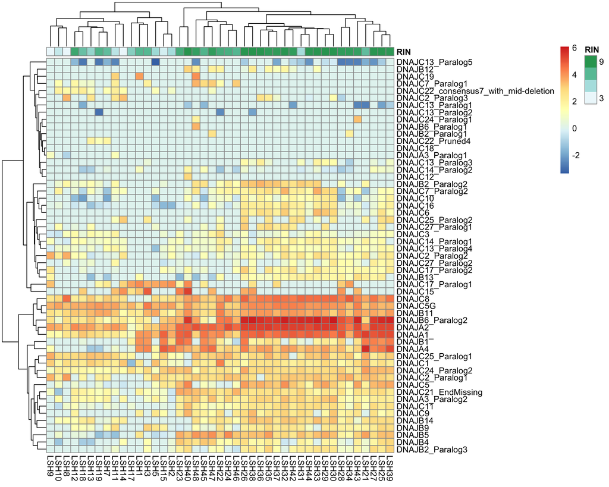

```r
annotatedHsps <- log(annotatedHsps)
annotatedHsps[annotatedHsps == -Inf] <- 0

annotRINs <- annot %>%
  dplyr::select(RIN)

pheatmap::pheatmap(data.matrix(annotatedHsps), annotation_col = annotRINs)
```

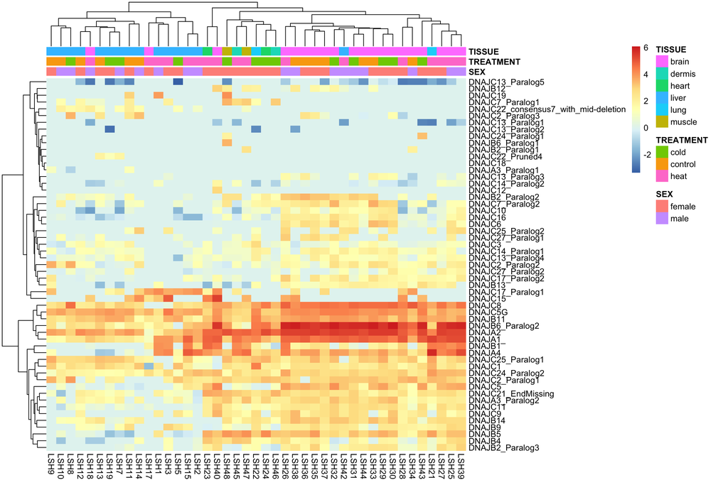

```r
annotPheno <- annot %>%
  dplyr::select(-RIN)

pheatmap::pheatmap(data.matrix(annotatedHsps), annotation_col = annotPheno)
```